# Covid-19 in the Philippines

## Introduction

### Covid-19 (Although it doesn't need any)

[figure not shown]

My Country **Republic of the Philippines**, is one of the high-risk countries from the Wuhan coronavirus outbreak, recorded the first death outside China. The government has announced lock-down of Metro Manila and is mulling over more localised lock-downs as the nCoV cases increase gradually and the WHO declaring coronavirus as a pandemic.

## Problem Which Tried to Solve:

### COVID-19 is wreaking havoc across the globe!!!

#### Well, that's something everyone probably already knows as long as they aren't living under the cave for some reason.

> - But is it really China who's the most affected right now?
> - Or one of those European countries that are literally on fire at the moment because of the virus?
> - How good is the US doing?
> - How on Earth did it spread so far? (See for yourself)
> - Will a public lockdown work?
> - Lessons to learn from China?
> - Should we be worried?

## The Location:

- **The Philippines** and the World

## The Audience:

- Everyone specially the **Filipinos**

## Imports

```python
import numpy as np # library to handle data in a vectorized manner
import pandas as pd # library for data analsysis
import requests

# use the inline backend to generate the plots within the browser
%matplotlib inline

import matplotlib as mpl
import matplotlib.pyplot as plt

mpl.style.use('ggplot') # optional: for ggplot-like style

import seaborn as sns
from sklearn import feature_extraction, linear_model, model_selection, preprocessing
from scipy.optimize import curve_fit
```

## The Data

The data below are gather from the COVID-19 repository by [**Johns Hopkins CSSE**](https://github.com/CSSEGISandData/COVID-19)

```python
# Global Data
confirmed_df = pd.read_csv('https://raw.githubusercontent.com/CSSEGISandData/COVID-19/master/csse_covid_19_data/csse_covid_19_time_series/time_series_covid19_confirmed_global.csv')
deaths_df = pd.read_csv('https://raw.githubusercontent.com/CSSEGISandData/COVID-19/master/csse_covid_19_data/csse_covid_19_time_series/time_series_covid19_deaths_global.csv')
recovered_df = pd.read_csv('https://raw.githubusercontent.com/CSSEGISandData/COVID-19/master/csse_covid_19_data/csse_covid_19_time_series/time_series_covid19_recovered_global.csv')
latest_data = pd.read_csv('https://raw.githubusercontent.com/CSSEGISandData/COVID-19/master/csse_covid_19_data/csse_covid_19_daily_reports/04-11-2020.csv')
```

The data below are downloaded from **Kaggle [Novel Coronavirus Philippine Dataset](https://www.kaggle.com/gigbytes/novel-coronavirus-philippine-dataset#facilities.csv)**

```python
cases_ph_df = pd.read_csv('cases_ph.csv')
facility_ph_df = pd.read_csv('facilities.csv')
```

## Gender Analysis

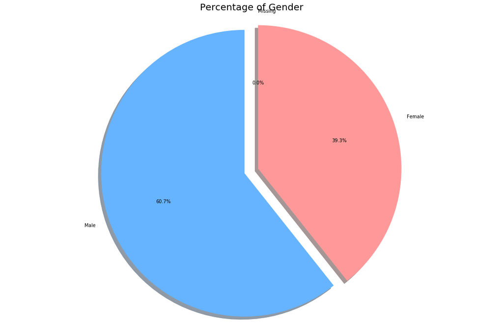

```python
labels = ['Missing', 'Male', 'Female']
sizes = []
sizes.append(cases_ph_df['sex'].isnull().sum())
sizes.append(list(cases_ph_df['sex'].value_counts())[0])
sizes.append(list(cases_ph_df['sex'].value_counts())[1])

explode = (0, 0.1, 0)
colors = ['#ffcc99','#66b3ff','#ff9999']

plt.figure(figsize= (15,10))
plt.title('Percentage of Gender',fontsize = 20)
plt.pie(sizes, explode=explode, labels=labels, colors=colors, autopct='%1.1f%%',shadow=True, startangle=90)
plt.axis('equal')
plt.tight_layout()
```

60.7% of COVID-19 positive patients are male. Men are the most most likely affected.

## The Philippines vs the other countries

### Total Confirmed, Recovered, Death in Philippines

```python
dates = list(confirmed_df.columns[4:])
dates = list(pd.to_datetime(dates))
dates_ph = dates[8:]
```

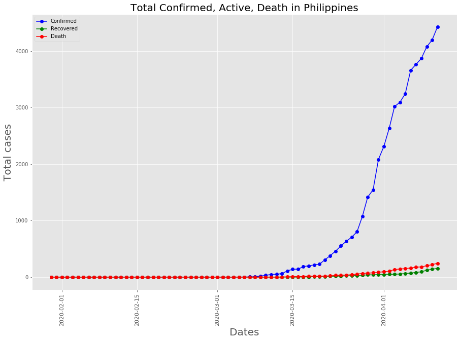

```python
df1 = confirmed_df.groupby('Country/Region').sum().reset_index()
df2 = deaths_df.groupby('Country/Region').sum().reset_index()
df3 = recovered_df.groupby('Country/Region').sum().reset_index()

k = df1[df1['Country/Region']=='Philippines'].loc[:,'1/30/20':]
ph_confirmed = k.values.tolist()[0]

k = df2[df2['Country/Region']=='Philippines'].loc[:,'1/30/20':]
ph_deaths = k.values.tolist()[0]

k = df3[df3['Country/Region']=='Philippines'].loc[:,'1/30/20':]
ph_recovered = k.values.tolist()[0]

plt.figure(figsize= (15,10))
plt.xticks(rotation = 90 ,fontsize = 11)
plt.yticks(fontsize = 10)
plt.xlabel("Dates",fontsize = 20)
plt.ylabel('Total cases',fontsize = 20)
plt.title("Total Confirmed, Active, Death in Philippines" , fontsize = 20)

ax1 = plt.plot_date(y= ph_confirmed,x= dates_ph,label = 'Confirmed',linestyle ='-',color = 'b')
ax2 = plt.plot_date(y= ph_recovered,x= dates_ph,label = 'Recovered',linestyle ='-',color = 'g')
ax3 = plt.plot_date(y= ph_deaths,x= dates_ph,label = 'Death',linestyle ='-',color = 'r')
plt.legend();
```

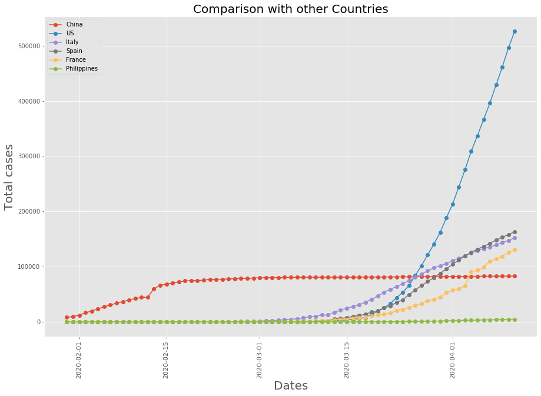

```python
countries = ['China','US', 'Italy', 'Spain', 'France','Philippines']

global_confirmed = []
global_recovered = []
global_deaths = []
global_active = []

for country in countries:
    k =df1[df1['Country/Region'] == country].loc[:,'1/30/20':]
    global_confirmed.append(k.values.tolist()[0])

    k =df2[df2['Country/Region'] == country].loc[:,'1/30/20':]
    global_deaths.append(k.values.tolist()[0])

    k =df3[df3['Country/Region'] == country].loc[:,'1/30/20':]
    global_deaths.append(k.values.tolist()[0])

plt.figure(figsize= (15,10))
plt.xticks(rotation = 90 ,fontsize = 11)
plt.yticks(fontsize = 10)
plt.xlabel("Dates",fontsize = 20)
plt.ylabel('Total cases',fontsize = 20)
plt.title("Comparison with other Countries" , fontsize = 20)

for i in range(len(countries)):
    plt.plot_date(y= global_confirmed[i],x= dates_ph,label = countries[i],linestyle ='-')
plt.legend();
```

1. One month Enhanced Community Quarantine imposed by Pres. Rodrigo Duterte
2. Low testing rate

# Prediction

## Prediction using growth factor

#### Assuming the same growth factor continues for the next 15 days

```python
df1 = confirmed_df.groupby('Country/Region').sum().reset_index()
df2 = deaths_df.groupby('Country/Region').sum().reset_index()
df3 = recovered_df.groupby('Country/Region').sum().reset_index()

k =df1[df1['Country/Region']=='Philippines'].loc[:,'2/4/20':]
india_confirmed = k.values.tolist()[0]

growth_diff = []

for i in range(1,len(ph_confirmed)):
    growth_diff.append(ph_confirmed[i] / ph_confirmed[i-1])

growth_factor = sum(growth_diff)/len(growth_diff)
print('Average growth factor',growth_factor)
```

```
Average growth factor 1.142653781184205
```

### Prediction for the next 15 days

```python
import datetime
prediction_dates = []

start_date = dates_ph[len(dates_ph) - 1]
for i in range(15):
    date = start_date + datetime.timedelta(days=1)
    prediction_dates.append(date)
    start_date = date

previous_day_cases = global_confirmed[5][len(dates_ph) - 1]
predicted_cases = []

for i in range(15):
    predicted_value = previous_day_cases *  growth_factor
    predicted_cases.append(predicted_value)
    previous_day_cases = predicted_value
```

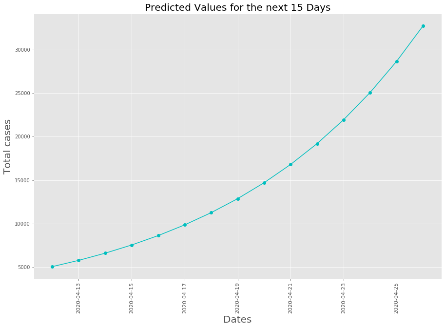

```python
plt.figure(figsize= (15,10))
plt.xticks(rotation = 90 ,fontsize = 11)
plt.yticks(fontsize = 10)
plt.xlabel("Dates",fontsize = 20)
plt.ylabel('Total cases',fontsize = 20)
plt.title("Predicted Values for the next 15 Days" , fontsize = 20)
ax1 = plt.plot_date(y= predicted_cases,x= prediction_dates,linestyle ='-',color = 'c')
```

We could see that the graph is increasing exponentialy if the average growth factor doesn't decrease. It is important that the growth factor is reduced to flatten the curve.

```python
# import training data
train_df = pd.read_csv("train.csv")
train_df['area'] = [str(i)+str(' - ')+str(j) for i,j in zip(train_df['Country_Region'], train_df['Province_State'])]
train_df['Date'] = pd.to_datetime(train_df['Date'])
train_df.head()
```

|  | Id | Province_State | Country_Region | Date | ConfirmedCases | Fatalities | area |
| --- | --- | --- | --- | --- | --- | --- | --- |
| 0 | 1 | NaN | Afghanistan | 2020-01-22 | 0.0 | 0.0 | Afghanistan - nan |
| 1 | 2 | NaN | Afghanistan | 2020-01-23 | 0.0 | 0.0 | Afghanistan - nan |
| 2 | 3 | NaN | Afghanistan | 2020-01-24 | 0.0 | 0.0 | Afghanistan - nan |
| 3 | 4 | NaN | Afghanistan | 2020-01-25 | 0.0 | 0.0 | Afghanistan - nan |
| 4 | 5 | NaN | Afghanistan | 2020-01-26 | 0.0 | 0.0 | Afghanistan - nan |

```python
# fuction for extracting data by Area
def get_country_data(df, area, metric):
    country_data = df[df['area']==area]
    country_data = country_data.drop(['Id','Province_State', 'Country_Region'], axis=1)
    country_data = pd.pivot_table(country_data, values=['ConfirmedCases','Fatalities'], index=['Date'], aggfunc=np.sum)
    country_data = country_data[country_data[metric]!=0]
    return country_data
```

```python
# functions for fitting the curve
def log_curve(x, k, x_0, ymax):
    return ymax / (1 + np.exp(-k*(x-x_0)))

def log_fit(train_df, area, metric):
    area_data = get_country_data(train_df, area, metric)
    x_data = range(len(area_data.index))
    y_data = area_data[metric]
    period = len(y_data)
    if period < 1:
        estimated_k = -1
        estimated_x_0 = -1
        ymax = -1
        total = 0
    elif max(y_data) == 0:
        estimated_k = -1
        estimated_x_0 = -1
        ymax = -1
        total = 0
    else:
        total = max(y_data)
        try:
            popt, pcov = curve_fit(log_curve, x_data, y_data, bounds=([0,0,0],np.inf), p0=[0.3,100,10000], maxfev=1000000)
            estimated_k, estimated_x_0, ymax = popt
        except RuntimeError:
            print(area)
            print("Error - curve_fit failed")
            estimated_k = -1
            estimated_x_0 = -1
            ymax = -1
    estimated_parameters = pd.DataFrame(np.array([[area, period, total, estimated_k, estimated_x_0, ymax]]),
                                        columns=['area', 'period', 'total', 'k', 'x_0', 'ymax'])
    return estimated_parameters
```

```python
# function for extracting th paramters for each Area
def get_parameters(metric):
    parameters = pd.DataFrame(columns=['area', 'period', 'total', 'k', 'x_0', 'ymax'], dtype=np.float)
    for area in train_df['area'].unique():
        estimated_parameters = log_fit(train_df, area, metric)
        parameters = parameters.append(estimated_parameters)
    parameters['period'] = pd.to_numeric(parameters['period'], downcast="float")
    parameters['total'] = pd.to_numeric(parameters['total'], downcast="float")
    parameters['k'] = pd.to_numeric(parameters['k'], downcast="float")
    parameters['x_0'] = pd.to_numeric(parameters['x_0'], downcast="float")
    parameters['ymax'] = pd.to_numeric(parameters['ymax'], downcast="float")
    parameters['Total Cases (absolute)'] = parameters['ymax']
    parameters['Longevity'] = 2*np.log(parameters['ymax']-1) / parameters['k']
    parameters['Rate of Spread (absolute)'] = parameters['k']*parameters['ymax']/4
    return parameters
```

```python
# extract the parameters
cases_parameters = get_parameters('ConfirmedCases')
deaths_parameters = get_parameters('Fatalities')
```

```python
# clean the parameter dataframes
cases_data = cases_parameters
cases_data = cases_data[cases_data['total']>=1000]
cases_data = cases_data[cases_data['period']>=20]
cases_data = cases_data[['area', 'Total Cases (absolute)', 'Longevity', 'Rate of Spread (absolute)']]
cases_data.head()
```

|  | area | Total Cases (absolute) | Longevity | Rate of Spread (absolute) |
| --- | --- | --- | --- | --- |
| 0 | Algeria - nan | 2197.427002 | 73.708969 | 114.696312 |
| 0 | Argentina - nan | 1961.757446 | 68.273460 | 108.916794 |
| 0 | Australia - New South Wales | 2820.521973 | 60.954758 | 183.801361 |
| 0 | Australia - Victoria | 1282.976807 | 59.019619 | 77.780792 |
| 0 | Austria - nan | 13027.141602 | 75.726021 | 814.967102 |

```python
# create fit prediction dataframe
predictions = pd.DataFrame(columns = ['area', 'date', 'ConfirmedCases', 'Fatalities', 'Fitted Cases', 'Fitted Fatalities'])
start = pd.to_datetime('20/01/2020')
numdays = 20*7
date_list = [start + datetime.timedelta(days=x) for x in range(numdays)]
for area in ['United Kingdom - nan', 'Italy - nan', 'Iran - nan', 'China - Hubei']: #train_df['area'].unique():
    area_cases_data = get_country_data(train_df, area, 'ConfirmedCases')
    cases_start_date = area_cases_data.index.min()
    offset = (cases_start_date - start).days
    x_data_fit = [i-offset for i in range(numdays)]
    x_data_real = range(1,len(area_cases_data.index)+1)
    parameters = cases_parameters
    estimated_k = parameters[parameters['area']==area]['k']
    estimated_x_0 = parameters[parameters['area']==area]['x_0']
    estimated_ymax = parameters[parameters['area']==area]['ymax']
    cases_fitted = log_curve(x_data_fit, np.float64(estimated_k), np.float64(estimated_x_0), np.float64(estimated_ymax))

    area_deaths_data = get_country_data(train_df, area, 'Fatalities')
    deaths_start_date = area_deaths_data.index.min()
    offset = (deaths_start_date - start).days
    x_data_fit = [i-offset for i in range(numdays)]
    x_data_real = range(1,len(area_deaths_data.index)+1)
    parameters = deaths_parameters
    estimated_k = parameters[parameters['area']==area]['k']
    estimated_x_0 = parameters[parameters['area']==area]['x_0']
    estimated_ymax = parameters[parameters['area']==area]['ymax']
    deaths_fitted = log_curve(x_data_fit, np.float64(estimated_k), np.float64(estimated_x_0), np.float64(estimated_ymax))

    area_predictions = pd.DataFrame(data={'area': [area]*numdays, 'date': date_list})
    area_predictions = area_predictions.merge(area_cases_data, left_on='date', right_index=True, how='left')
    area_predictions['Fitted Cases'] = cases_fitted
    area_predictions['Fitted Fatalities'] = deaths_fitted

    predictions = predictions.append(area_predictions)
```

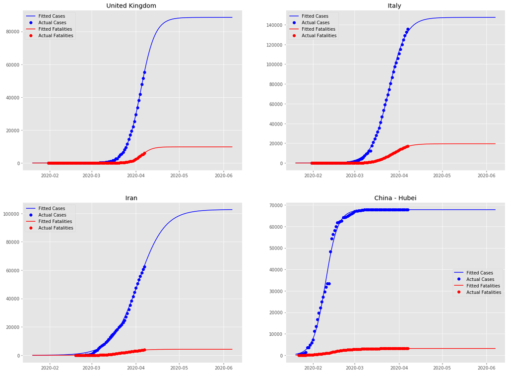

```python
# plot some example fits
fig, ((ax1, ax2), (ax3, ax4)) = plt.subplots(2, 2, figsize=(20,15))
areas = ['United Kingdom - nan', 'Italy - nan', 'Iran - nan', 'China - Hubei']
axs = [ax1, ax2, ax3, ax4]
for i in range(len(areas)):
    area = areas[i]
    axs[i].set_title(area.replace("- nan", ""))
    area_predictions = predictions[predictions['area']==area]
    axs[i].plot(area_predictions['date'], area_predictions['Fitted Cases'], label='Fitted Cases', color='b')
    axs[i].plot(area_predictions['date'], area_predictions['ConfirmedCases'], 'o', label='Actual Cases', color='b')
    axs[i].plot(area_predictions['date'], area_predictions['Fitted Fatalities'], '-', label='Fitted Fatalities', color='r')
    axs[i].plot(area_predictions['date'], area_predictions['Fatalities'], 'o', label='Actual Fatalities', color='r')
    axs[i].legend()
```

# Correlating the Metadata

In this section various factors about the Area are correlated to the fit parameters

```python
# import metadata and join to the parameter data
area_data = pd.read_csv("covid19countryinfo.csv")
area_data['area'] = [str(i)+str(' - ')+str(j) for i,j in zip(area_data['country'], area_data['region'])]

full_data = cases_data.merge(area_data, on='area', how='left')
full_data['pop'] = pd.to_numeric(full_data['pop'].str.replace(',', ''), downcast="float")
full_data = full_data[full_data['Total Cases (absolute)']<full_data['pop']]
```

```python
# create the factors for correlation
full_data['firstcase'] = pd.to_datetime(full_data['firstcase'])
date_metrics = ['quarantine', 'schools', 'publicplace', 'gathering', 'nonessential']
for metric in date_metrics:
    full_data[metric] = pd.to_datetime(full_data[metric])
    new_metric = 'days_to_'+metric
    full_data[new_metric] = (full_data[metric]-full_data['firstcase']).dt.days
    #full_data[new_metric] = full_data[new_metric].fillna(full_data['Longevity'])

full_data['Tests per Citizen'] = 1/full_data['testpop']
full_data['Hospital Beds per Citizen'] = full_data['hospibed']/1000
full_data = full_data.rename(columns={"density": "Population Density",
                                      "medianage": "Median Age",
                                      "urbanpop": "Urban Poulation %",
                                      "avgtemp": "Average Temperature",
                                      "avghumidity": "Average Humidity"})
```

```python
# normalise metrics against Area population
norm_data = full_data
norm_data['Total Cases'] = norm_data['Total Cases (absolute)']/norm_data['pop']
norm_data['Rate of Spread'] = norm_data['Rate of Spread (absolute)']/norm_data['pop']
norm_data.head()
```

|  | area | Total Cases (absolute) | Longevity | Rate of Spread (absolute) | region | country | alpha3code | alpha2code | pop | tests | ... | deathdiv1m | days_to_quarantine | days_to_schools | days_to_publicplace | days_to_gathering | days_to_nonessential | Tests per Citizen | Hospital Beds per Citizen | Total Cases | Rate of Spread |
| --- | --- | --- | --- | --- | --- | --- | --- | --- | --- | --- | --- | --- | --- | --- | --- | --- | --- | --- | --- | --- | --- |
| 0 | Algeria - nan | 2197.427002 | 73.708969 | 114.696312 | NaN | Algeria | DZA | DZ | 43851044.0 | NaN | ... | 1.0 | NaN | NaN | NaN | NaN | NaN | NaN | 0.0019 | 0.000050 | 0.000003 |
| 1 | Argentina - nan | 1961.757446 | 68.273460 | 108.916794 | NaN | Argentina | ARG | AR | 45195776.0 | NaN | ... | 0.6 | 18.0 | NaN | NaN | NaN | NaN | NaN | 0.0050 | 0.000043 | 0.000002 |
| 4 | Austria - nan | 13027.141602 | 75.726021 | 814.967102 | NaN | Austria | AUT | AT | 9006398.0 | 10278.0 | ... | 14.0 | 21.0 | NaN | NaN | NaN | NaN | 0.001141 | 0.0076 | 0.001446 | 0.000090 |
| 5 | Belgium - nan | 27904.085938 | 98.335777 | 1452.370361 | NaN | Belgium | BEL | BE | 11589623.0 | 4225.0 | ... | 61.0 | 44.0 | NaN | NaN | NaN | NaN | 0.000365 | 0.0062 | 0.002408 | 0.000125 |
| 6 | Brazil - nan | 26576.662109 | 108.572914 | 1246.887451 | NaN | Brazil | BRA | BR | 212559424.0 | 2927.0 | ... | 0.8 | NaN | NaN | NaN | NaN | NaN | 0.000014 | 0.0022 | 0.000125 | 0.000006 |

5 rows × 59 columns

```python
# select the metrics and factors to correlate
metrics = ['Total Cases', 'Longevity', 'Rate of Spread']
factors = ['Tests per Citizen', 'Hospital Beds per Citizen', "Population Density", "Median Age", "Urban Poulation %", "Average Temperature", "Average Humidity", 'days_to_quarantine', 'days_to_schools', 'days_to_publicplace', 'days_to_gathering', 'days_to_nonessential']
```

```python
# calculate the correlation coefficient map
corr_matrix = norm_data.corr(method ='spearman')
corr_matrix = corr_matrix[metrics].filter(factors, axis = 0)
cm = sns.diverging_palette(20, 133, sep=20, as_cmap=True)
corr_matrix.style.background_gradient(cmap=cm)
```

|  | Total Cases | Longevity | Rate of Spread |
| --- | --- | --- | --- |
| Tests per Citizen | 0.510695 | 0.189505 | 0.497326 |
| Hospital Beds per Citizen | 0.343409 | -0.0995061 | 0.418315 |
| Population Density | 0.242876 | 0.180737 | 0.26655 |
| Median Age | 0.505136 | 0.178294 | 0.515536 |
| Urban Poulation % | 0.263908 | 0.0854773 | 0.244264 |
| days_to_quarantine | 0.379991 | 0.459851 | 0.446687 |
| days_to_schools | 0.507512 | 0.425689 | 0.500262 |
| days_to_publicplace | 0.744776 | 0.460255 | 0.753145 |
| days_to_gathering | 0.299407 | 0.38324 | 0.347312 |
| days_to_nonessential | 0.4 | 0.8 | 0.4 |